# Houston and the Texas legislative common space

A six-person bridge diagnostic, not yet a validated map

Published

September 27, 2026

## Finding

The [Shor, Berry, and McCarty bridge procedure](https://bshor.github.io/files/papers/shor_etal_2010_bridge_to_somewhere.pdf) can be run for Houston: six people in the 2000–2026 council fit also have scores in the Texas state-legislative common-space file. But **these six do not calibrate a credible Houston-to-Texas scale**. They are all Democrats and occupy a restricted part of both scales. Within that narrow range, the estimated slope is 0.12, its 95% interval runs from -0.63 to 0.86, and $R^2 = 0.04$. The small correlation does **not** establish that these people changed ideology across offices; this anchor set simply cannot identify a reliable mapping over the full council spectrum.

The 2010 paper finds in simulation that linear mapping can work well with as few as four bridge actors when their ideological positions are consistent across institutions. That is a result about *informative bridges*, not a promise that any four—or six—will cover the relevant ideological range. Houston’s six anchors have no Republican or conservative counterpart, so the data cannot separate range restriction from cross-institutional change or measurement error. The method here matches the New York city-to-state implementation in form, but its empirical support is much weaker.

## The bridge observations

The city side is the selected-mode, pooled Houston roll-call estimate for 77 people and 939 divided actions. The target is `TX_common_scores.csv` from `/data/School/Research/Votesmart/Output/Scores/Legislatures_2026/`, SHA-256 `e2226eda3bb79034f96515ad8c4f76da527c6184beb887e177cc065009355e4a`. That file has 957 state legislators (517 D, 440 R), pooled across years and chambers, not a single sitting Texas legislature. The six links were checked as people who actually served in both institutions, not made by surname alone. Melissa Noriega’s short state service was as a substitute legislator; John Whitmire’s and Sylvester Turner’s city roles are mayoral.

| Houston official | Office sequence | Houston score | Texas score | Identity source |
| --- | --- | --- | --- | --- |
| Jarvis Johnson | council to state House | -1.21 | -1.07 | [record](https://lrl.texas.gov/legeLeaders/members/memberDisplay.cfm?memberID=5795) |
| Ellen Cohen | state House to council | -0.91 | -1.08 | [record](https://www.lrl.texas.gov/legeLeaders/members/memberDisplay.cfm?memberID=5633) |
| Sylvester Turner | state House to mayor | -0.68 | -0.83 | [record](https://history.house.gov/People/Detail/36507225799) |
| Melissa Noriega | state House to council | -0.45 | -1.50 | [record](https://melissanoriega.com/about/) |
| Carol Alvarado | council to state House/Senate | -0.41 | -1.33 | [record](https://senate.texas.gov/member.php?d=6) |
| John Whitmire | state House/Senate to mayor | +0.30 | -0.76 | [record](https://www.houstontx.gov/mayor/bio.html) |

## Linear map and checks

Following the paper, the mapping is ordinary least squares of the Texas score on the Houston score over the bridge people. The fitted equation is **Texas score = -1.03 +0.12 × Houston score**. Each person is one observation, irrespective of how many votes they cast; state-score errors are shown but not used as regression weights, matching the original linear-map step.

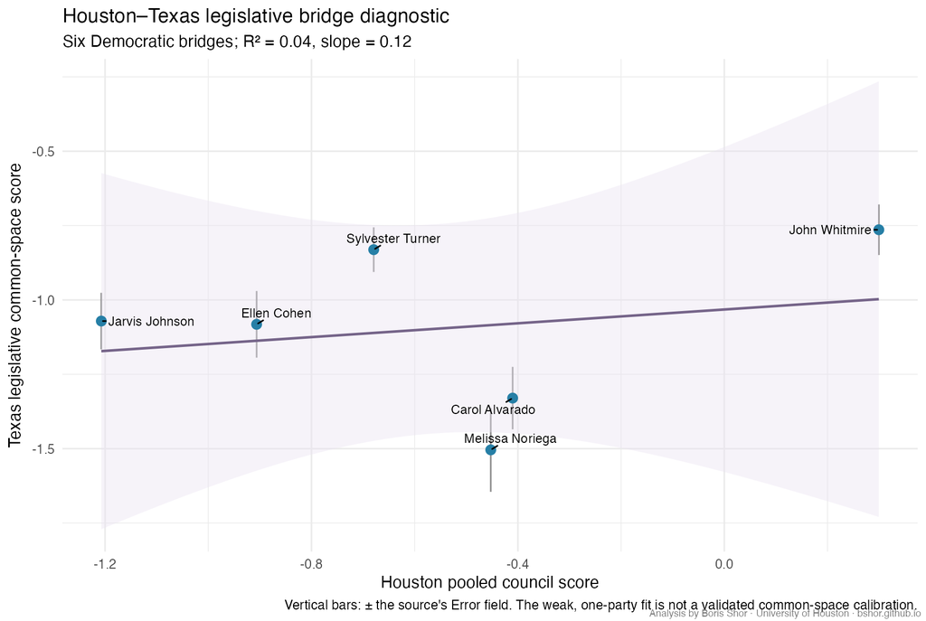

The [leave-one-bridge-out check](https://bshor.github.io/files/papers/shor_etal_2010_bridge_to_somewhere.pdf) is especially revealing. The root-mean-square held-out error is 0.45 Texas units. Dropping Whitmire changes the slope from positive to -0.43 and predicts his state score at -1.61, versus his observed -0.76. Using only the four people who bridged as *council members*, not mayors, also yields a negative slope (-0.48). That is a sensitivity result, not a basis for choosing a preferred subsample.

| Held-out official | Observed Texas | Predicted Texas | Prediction error | Slope without |
| --- | --- | --- | --- | --- |
| Carol Alvarado | -1.33 | -1.02 | +0.31 | +0.15 |
| Ellen Cohen | -1.08 | -1.16 | -0.07 | +0.14 |
| Jarvis Johnson | -1.07 | -1.27 | -0.20 | +0.21 |
| John Whitmire | -0.76 | -1.61 | -0.84 | -0.43 |
| Melissa Noriega | -1.50 | -1.00 | +0.51 | +0.16 |
| Sylvester Turner | -0.83 | -1.17 | -0.34 | +0.15 |

The bridge members span Houston scores from -1.21 to +0.30, while the fitted council extends from -1.65 to +4.27. Their Texas scores cover only 0.74 units, compared with 7.11 across the pooled state file. **30 of 77** fitted officials lie outside the observed Houston bridge range, including **25 of 31** Republican-affiliated officials. Their Texas placements would be extrapolations from Democratic-only anchors.

The plot below is deliberately a *failure diagnostic*: it applies the estimated formula mechanically to the 17 officials in the 2023-elected council and places those ticks against the pooled Texas party distributions. The nearly flat slope compresses even Houston’s Republican-affiliated members into the Texas Democratic range. This is **not** evidence that Houston Republicans vote like Texas Democrats; it shows why the present mapping should not be interpreted.

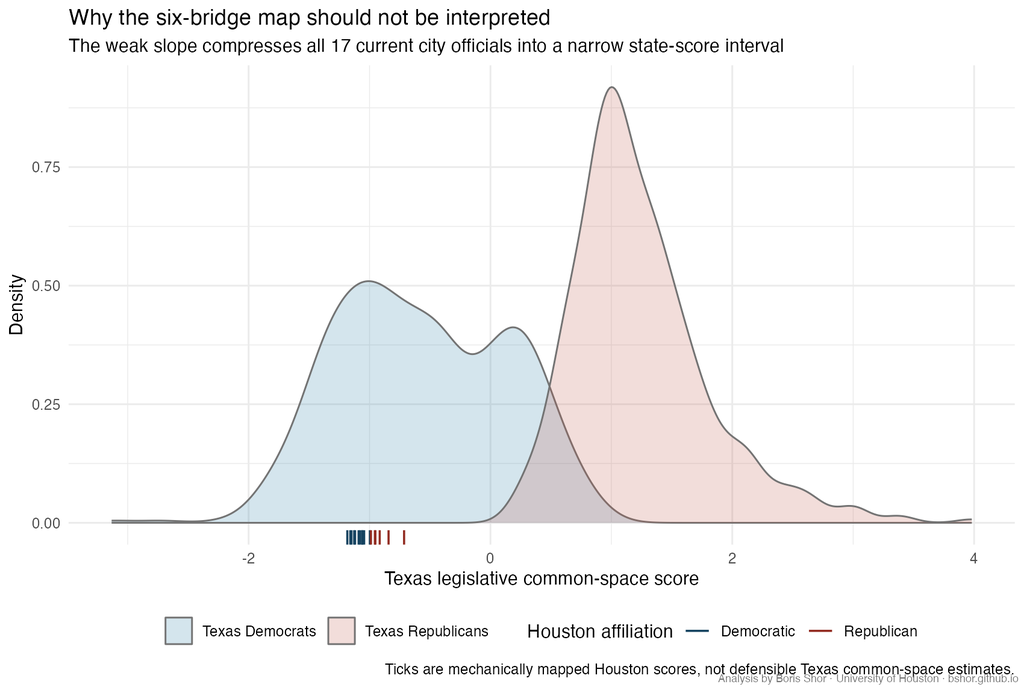

## What would improve it

The next useful test is not merely adding any four names. We need bridges covering **both ends** of Houston’s voting scale, independently linked to a score on the same target scale, and a leave-one-out check that does not reverse the slope. Only then would it be useful to assess whether agenda, time, or individual change also disrupt the mapping. The earlier 2003–2026 council fit gives the same qualitative result (six bridges, $R^2$ about 0.08), so the new 2000–2003 backfill is not the source of the thin anchor coverage. Until a wider bridge set is assembled, the Houston ideal points should remain on their city-specific scale.

### Reproduction

Run `Rscript Code/39_houston_state_bridge.r` from the Local project root. Its exact-link ledger, regression, leave-one-out diagnostics, and mechanically mapped *diagnostic* file are under `Results/Houston-2000/state_bridge/`. The script never alters the Houston model or its published expanded report.